# ExtraaLearn Project

## Context

The EdTech industry has been surging in the past decade immensely, and according to a forecast, the Online Education market would be worth $286.62bn by 2023 with a compound annual growth rate (CAGR) of 10.26% from 2018 to 2023. The modern era of online education has enforced a lot in its growth and expansion beyond any limit. Due to having many dominant features like ease of information sharing, personalized learning experience, transparency of assessment, etc, it is now preferable to traditional education.

In the present scenario due to the Covid-19, the online education sector has witnessed rapid growth and is attracting a lot of new customers. Due to this rapid growth, many new companies have emerged in this industry. With the availability and ease of use of digital marketing resources, companies can reach out to a wider audience with their offerings. The customers who show interest in these offerings are termed as leads. There are various sources of obtaining leads for Edtech companies, like

- The customer interacts with the marketing front on social media or other online platforms.
- The customer browses the website/app and downloads the brochure
- The customer connects through emails for more information.

The company then nurtures these leads and tries to convert them to paid customers. For this, the representative from the organization connects with the lead on call or through email to share further details.

## Objective

ExtraaLearn is an initial stage startup that offers programs on cutting-edge technologies to students and professionals to help them upskill/reskill. With a large number of leads being generated on a regular basis, one of the issues faced by ExtraaLearn is to identify which of the leads are more likely to convert so that they can allocate resources accordingly. You, as a data scientist at ExtraaLearn, have been provided the leads data to:

- Analyze and build an ML model to help identify which leads are more likely to convert to paid customers,
- Find the factors driving the lead conversion process
- Create a profile of the leads which are likely to convert

## Data Description

The data contains the different attributes of leads and their interaction details with ExtraaLearn. The detailed data dictionary is given below.

**Data Dictionary**

- ID: ID of the lead
- age: Age of the lead
- current_occupation: Current occupation of the lead. Values include 'Professional','Unemployed',and 'Student'
- first_interaction: How did the lead first interacted with ExtraaLearn. Values include 'Website', 'Mobile App'
- profile_completed: What percentage of profile has been filled by the lead on the website/mobile app. Values include Low - (0-50%), Medium - (50-75%), High (75-100%)
- website_visits: How many times has a lead visited the website
- time_spent_on_website: Total time spent on the website
- page_views_per_visit: Average number of pages on the website viewed during the visits.
- last_activity: Last interaction between the lead and ExtraaLearn.
  - Email Activity: Seeking for details about program through email, Representative shared information with lead like brochure of program , etc
  - Phone Activity: Had a Phone Conversation with representative, Had conversation over SMS with representative, etc
  - Website Activity: Interacted on live chat with representative, Updated profile on website, etc
- print_media_type1: Flag indicating whether the lead had seen the ad of ExtraaLearn in the Newspaper.
- print_media_type2: Flag indicating whether the lead had seen the ad of ExtraaLearn in the Magazine.
- digital_media: Flag indicating whether the lead had seen the ad of ExtraaLearn on the digital platforms.
- educational_channels: Flag indicating whether the lead had heard about ExtraaLearn in the education channels like online forums, discussion threads, educational websites, etc.
- referral: Flag indicating whether the lead had heard about ExtraaLearn through reference.
- status: Flag indicating whether the lead was converted to a paid customer or not.

## Importing necessary libraries and data

```python
# Importing the basic libraraies for the project

# Importing numpy and pandas
import numpy as np
import pandas as pd

# For data visualization
import matplotlib.pyplot as plt
import seaborn as sns
sns.set()

# Machine Learning models from Scikit-Learn
from sklearn.linear_model import LogisticRegression
from sklearn.svm import SVC
from sklearn.ensemble import RandomForestClassifier
from sklearn import tree
from sklearn.tree import DecisionTreeClassifier

# Other functions
from sklearn.preprocessing import OneHotEncoder, LabelEncoder, StandardScaler, MinMaxScaler
from sklearn.model_selection import GridSearchCV, train_test_split

# Importing different metrics scores
from sklearn.metrics import confusion_matrix,roc_curve,roc_auc_score,classification_report,precision_recall_curve,make_scorer

# Code to ignore warnings
import warnings
warnings.filterwarnings("ignore")
```

## Data Overview

- Observations
- Sanity checks

# **Loading the data**

```python
from google.colab import drive
drive.mount('/content/drive')
```

```python
data = pd.read_csv('/content/drive/MyDrive/Project 2/ExtraaLearn.csv')
```

# **Overview of the data**

The first five and last five rows of the data using the necessary code.

```python
data.head()
```

|  | ID | age | current_occupation | first_interaction | profile_completed | website_visits | time_spent_on_website | page_views_per_visit | last_activity | print_media_type1 | print_media_type2 | digital_media | educational_channels | referral | status |
| --- | --- | --- | --- | --- | --- | --- | --- | --- | --- | --- | --- | --- | --- | --- | --- |
| 0 | EXT001 | 57 | Unemployed | Website | High | 7 | 1639 | 1.861 | Website Activity | Yes | No | Yes | No | No | 1 |
| 1 | EXT002 | 56 | Professional | Mobile App | Medium | 2 | 83 | 0.320 | Website Activity | No | No | No | Yes | No | 0 |
| 2 | EXT003 | 52 | Professional | Website | Medium | 3 | 330 | 0.074 | Website Activity | No | No | Yes | No | No | 0 |
| 3 | EXT004 | 53 | Unemployed | Website | High | 4 | 464 | 2.057 | Website Activity | No | No | No | No | No | 1 |
| 4 | EXT005 | 23 | Student | Website | High | 4 | 600 | 16.914 | Email Activity | No | No | No | No | No | 0 |

```python
data.tail()
```

|  | ID | age | current_occupation | first_interaction | profile_completed | website_visits | time_spent_on_website | page_views_per_visit | last_activity | print_media_type1 | print_media_type2 | digital_media | educational_channels | referral | status |
| --- | --- | --- | --- | --- | --- | --- | --- | --- | --- | --- | --- | --- | --- | --- | --- |
| 4607 | EXT4608 | 35 | Unemployed | Mobile App | Medium | 15 | 360 | 2.170 | Phone Activity | No | No | No | Yes | No | 0 |
| 4608 | EXT4609 | 55 | Professional | Mobile App | Medium | 8 | 2327 | 5.393 | Email Activity | No | No | No | No | No | 0 |
| 4609 | EXT4610 | 58 | Professional | Website | High | 2 | 212 | 2.692 | Email Activity | No | No | No | No | No | 1 |
| 4610 | EXT4611 | 57 | Professional | Mobile App | Medium | 1 | 154 | 3.879 | Website Activity | Yes | No | No | No | No | 0 |
| 4611 | EXT4612 | 55 | Professional | Website | Medium | 4 | 2290 | 2.075 | Phone Activity | No | No | No | No | No | 0 |

Shape and information about the data

```python
data.shape
```

```
(4612, 15)
```

```python
data.info()
```

```
<class 'pandas.core.frame.DataFrame'>
RangeIndex: 4612 entries, 0 to 4611
Data columns (total 15 columns):
 #   Column                 Non-Null Count  Dtype
---  ------                 --------------  -----
 0   ID                     4612 non-null   object
 1   age                    4612 non-null   int64
 2   current_occupation     4612 non-null   object
 3   first_interaction      4612 non-null   object
 4   profile_completed      4612 non-null   object
 5   website_visits         4612 non-null   int64
 6   time_spent_on_website  4612 non-null   int64
 7   page_views_per_visit   4612 non-null   float64
 8   last_activity          4612 non-null   object
 9   print_media_type1      4612 non-null   object
 10  print_media_type2      4612 non-null   object
 11  digital_media          4612 non-null   object
 12  educational_channels   4612 non-null   object
 13  referral               4612 non-null   object
 14  status                 4612 non-null   int64
dtypes: float64(1), int64(4), object(10)
memory usage: 540.6+ KB
```

# **Missing values in the data**

```python
data.isna().sum()
```

```
ID                       0
age                      0
current_occupation       0
first_interaction        0
profile_completed        0
website_visits           0
time_spent_on_website    0
page_views_per_visit     0
last_activity            0
print_media_type1        0
print_media_type2        0
digital_media            0
educational_channels     0
referral                 0
status                   0
dtype: int64
```

# **Uniques values in the data**

```python
data.nunique()
```

```
ID                       4612
age                        46
current_occupation          3
first_interaction           2
profile_completed           3
website_visits             27
time_spent_on_website    1623
page_views_per_visit     2414
last_activity               3
print_media_type1           2
print_media_type2           2
digital_media               2
educational_channels        2
referral                    2
status                      2
dtype: int64
```

**Observation:** The column with the most unique value is the ID. Since it is unique, we would not require it.

```python
# Dropping the column with most unique values
data = data.drop('ID', axis=1)
```

# **Statistical summary of the data**

```python
data.describe().T
```

|  | count | mean | std | min | 25% | 50% | 75% | max |
| --- | --- | --- | --- | --- | --- | --- | --- | --- |
| age | 4612.0 | 46.201214 | 13.161454 | 18.0 | 36.00000 | 51.000 | 57.00000 | 63.000 |
| website_visits | 4612.0 | 3.566782 | 2.829134 | 0.0 | 2.00000 | 3.000 | 5.00000 | 30.000 |
| time_spent_on_website | 4612.0 | 724.011275 | 743.828683 | 0.0 | 148.75000 | 376.000 | 1336.75000 | 2537.000 |
| page_views_per_visit | 4612.0 | 3.026126 | 1.968125 | 0.0 | 2.07775 | 2.792 | 3.75625 | 18.434 |
| status | 4612.0 | 0.298569 | 0.457680 | 0.0 | 0.00000 | 0.000 | 1.00000 | 1.000 |

**Observation:**

- The age of the leads has an average of 46 years where the minimum age was 18 years and the maximum was 63 years
- On average, most of the leads visited the website at around 3-4 times. The maximum number of times that the website was visited is 30 times.
- 3 webpages are viewed every visit on an average basis and the maximum was around 18 pages in a visit.
- Almost 30% or 29.857% precisely, have become paid customers.

**Count of each unique category of each categorical variable**

```python
# Making a list of all categorical variables
cat_col = ['current_occupation', 'first_interaction', 'last_activity', 'educational_channels', 'referral', 'digital_media',
           'print_media_type1', 'print_media_type2', 'profile_completed', 'status']

# Number of count of each unique values
for column in cat_col:
  print(data[column].value_counts(normalize=True))
  print('-'*50)
```

```
Professional    0.567216
Unemployed      0.312446
Student         0.120338
Name: current_occupation, dtype: float64
--------------------------------------------------
Website       0.551171
Mobile App    0.448829
Name: first_interaction, dtype: float64
--------------------------------------------------
Email Activity      0.493929
Phone Activity      0.267563
Website Activity    0.238508
Name: last_activity, dtype: float64
--------------------------------------------------
No     0.847138
Yes    0.152862
Name: educational_channels, dtype: float64
--------------------------------------------------
No     0.979835
Yes    0.020165
Name: referral, dtype: float64
--------------------------------------------------
No     0.885733
Yes    0.114267
Name: digital_media, dtype: float64
--------------------------------------------------
No     0.892238
Yes    0.107762
Name: print_media_type1, dtype: float64
--------------------------------------------------
No     0.94948
Yes    0.05052
Name: print_media_type2, dtype: float64
--------------------------------------------------
High      0.490893
Medium    0.485906
Low       0.023200
Name: profile_completed, dtype: float64
--------------------------------------------------
0    0.701431
1    0.298569
Name: status, dtype: float64
--------------------------------------------------
```

**Observations**

**Note:**

- Here '1' in status means that the customer has successfully been converted into a paid customer
- whereas '0' in status means they have not converted into a paid customer

```python
# Converting the above categorical variables to 'category' datatype
for column in cat_col:
  data[column] = data[column].astype('category')
```

```python
# Converting the numerical column datatypes to float
num_cols = ['age', 'website_visits', 'page_views_per_visit', 'time_spent_on_website']
for col in num_cols:
  data[col] = data[col].astype('float')
```

```python
data.info()
```

```
<class 'pandas.core.frame.DataFrame'>
RangeIndex: 4612 entries, 0 to 4611
Data columns (total 14 columns):
 #   Column                 Non-Null Count  Dtype
---  ------                 --------------  -----
 0   age                    4612 non-null   float64
 1   current_occupation     4612 non-null   category
 2   first_interaction      4612 non-null   category
 3   profile_completed      4612 non-null   category
 4   website_visits         4612 non-null   float64
 5   time_spent_on_website  4612 non-null   float64
 6   page_views_per_visit   4612 non-null   float64
 7   last_activity          4612 non-null   category
 8   print_media_type1      4612 non-null   category
 9   print_media_type2      4612 non-null   category
 10  digital_media          4612 non-null   category
 11  educational_channels   4612 non-null   category
 12  referral               4612 non-null   category
 13  status                 4612 non-null   category
dtypes: category(10), float64(4)
memory usage: 190.5 KB
```

```python
same_data = data.copy()
```

## Exploratory Data Analysis (EDA)

- EDA is an important part of any project involving data.
- It is important to investigate and understand the data better before building a model with it.
- A few questions have been mentioned below which will help you approach the analysis in the right manner and generate insights from the data.
- A thorough analysis of the data, in addition to the questions mentioned below, should be done.

**Questions**

1. Leads will have different expectations from the outcome of the course and the current occupation may play a key role in getting them to participate in the program. Find out how current occupation affects lead status.
2. The company's first impression on the customer must have an impact. Do the first channels of interaction have an impact on the lead status?
3. The company uses multiple modes to interact with prospects. Which way of interaction works best?
4. The company gets leads from various channels such as print media, digital media, referrals, etc. Which of these channels have the highest lead conversion rate?
5. People browsing the website or mobile application are generally required to create a profile by sharing their personal data before they can access additional information.Does having more details about a prospect increase the chances of conversion?

## Data Preprocessing

- Missing value treatment (if needed)
- Feature engineering (if needed)
- Outlier detection and treatment (if needed)
- Preparing data for modeling
- Any other preprocessing steps (if needed)

**Seperating independent variables (X) from the the dependent variables (Y)**

```python
# Seperating our target variable from other variables
X = data.drop(columns='status', axis=1)
y = data['status']
```

```python
data.groupby(['status'])[num_cols].mean()
```

| status | age | website_visits | page_views_per_visit | time_spent_on_website |
| --- | --- | --- | --- | --- |
| 0 | 45.153014 | 3.578980 | 3.025732 | 577.420711 |
| 1 | 48.663762 | 3.538126 | 3.027050 | 1068.397967 |

**Converting 'Yes' and 'No' to '1' and '0'**

**As we try to predict that helps in determining the factors that converts normal customers to paid ones, we may not need factors such as `last_activity` and `profile_completed`.**

```python
X.drop(columns=['profile_completed','last_activity'], inplace=True)
```

**Splitting the data into 80% train and 20% test set**

```python
X_train, X_test, y_train, y_test = train_test_split(X, y, test_size=0.2, random_state=1, stratify=y)
```

```python
# List of all dummy columns
columns_dummy = ['current_occupation', 'first_interaction']

# Creating the dummy variables
X_train = pd.get_dummies(X_train, columns = columns_dummy, drop_first=True)
X_test = pd.get_dummies(X_test, columns= columns_dummy, drop_first = True)
```

```python
# Replacing the 'No' with 0
X_train['referral'] = X_train['referral'].replace('No', 0)
X_train['digital_media'] = X_train['digital_media'].replace('No', 0)
X_train['educational_channels'] = X_train['educational_channels'].replace('No', 0)
X_train['print_media_type1'] = X_train['print_media_type1'].replace('No', 0)
X_train['print_media_type2'] = X_train['print_media_type2'].replace('No', 0)
X_test['referral'] = X_test['referral'].replace('No', 0)
X_test['digital_media'] = X_test['digital_media'].replace('No', 0)
X_test['educational_channels'] = X_test['educational_channels'].replace('No', 0)
X_test['print_media_type1'] = X_test['print_media_type1'].replace('No', 0)
X_test['print_media_type2'] = X_test['print_media_type2'].replace('No', 0)
```

```python
# Replacing the 'Yes' with 1
X_train['referral'] = X_train['referral'].replace('Yes', 1)
X_train['digital_media'] = X_train['digital_media'].replace('Yes', 1)
X_train['educational_channels'] = X_train['educational_channels'].replace('Yes', 1)
X_train['print_media_type1'] = X_train['print_media_type1'].replace('Yes', 1)
X_train['print_media_type2'] = X_train['print_media_type2'].replace('Yes', 1)
X_test['referral'] = X_test['referral'].replace('Yes', 1)
X_test['digital_media'] = X_test['digital_media'].replace('Yes', 1)
X_test['educational_channels'] = X_test['educational_channels'].replace('Yes', 1)
X_test['print_media_type1'] = X_test['print_media_type1'].replace('Yes', 1)
X_test['print_media_type2'] = X_test['print_media_type2'].replace('Yes', 1)
```

```python
# Converting the data types of the columns to float
for column in ['print_media_type1', 'print_media_type2', 'referral', 'digital_media', 'educational_channels']:
  X_train[column] = X_train[column].astype(float)
  X_test[column] = X_test[column].astype(float)
```

```python
# Scaling the data
scaling = StandardScaler()

# Fit and transform the train data
X_train_scaled = scaling.fit_transform(X_train)
X_train_scaled = pd.DataFrame(X_test, columns=X.columns)

# Fit and transform the test data
X_test_scaled = scaling.fit_transform(X_test)
X_test_scaled = pd.DataFrame(X_test, columns=X.columns)
```

## EDA

- It is a good idea to explore the data once again after manipulating it.

# **Univariate Analysis**

```python
# Creating a function to plot both the histogram and boxplot
def histo_box(data, column):
  f, (ax_box, ax_histo) = plt.subplots(nrows=2, sharex=True, gridspec_kw={'height_ratios':(0.75,0.25)}, figsize=(13,10))
  # Histogram design
  sns.histplot(data=data, x=column, ax=ax_histo, kde=True)
  plt.axvline(data[column].mean(), color='purple', linestyle = '--') # Line to represent the mean
  plt.axvline(data[column].median(), color='green', linestyle='--') # Line to represent the median
  plt.xlabel(column)
  # Boxplot design
  sns.boxplot(data=data, x=column, ax=ax_box, showmeans = True)
```

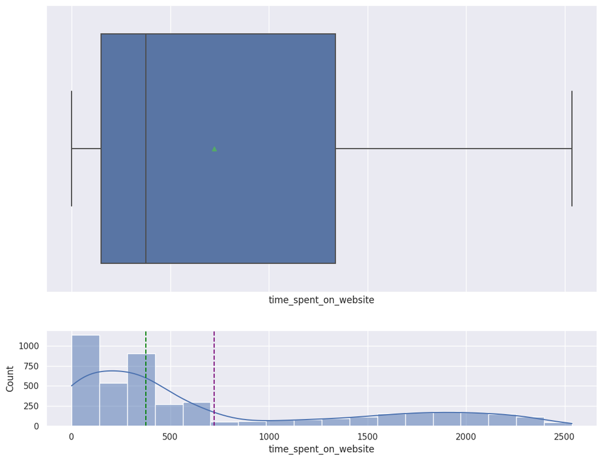

```python
histo_box(data, 'time_spent_on_website')
```

**Observations:**

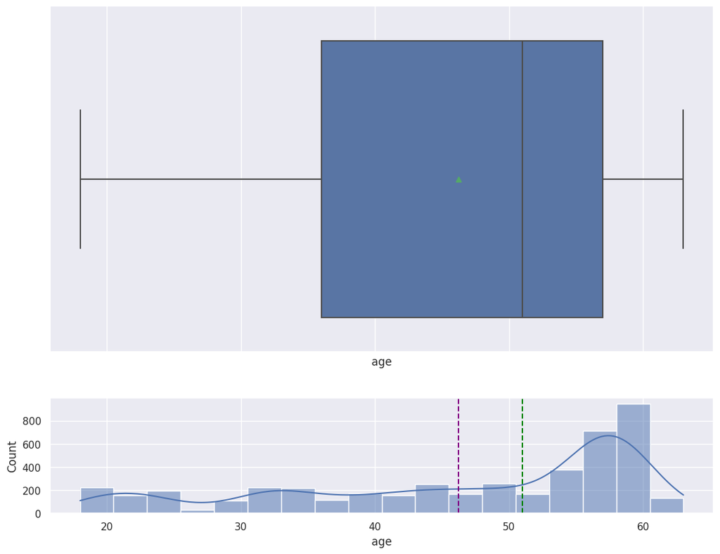

```python
histo_box(data, 'age')
```

**Observations:**

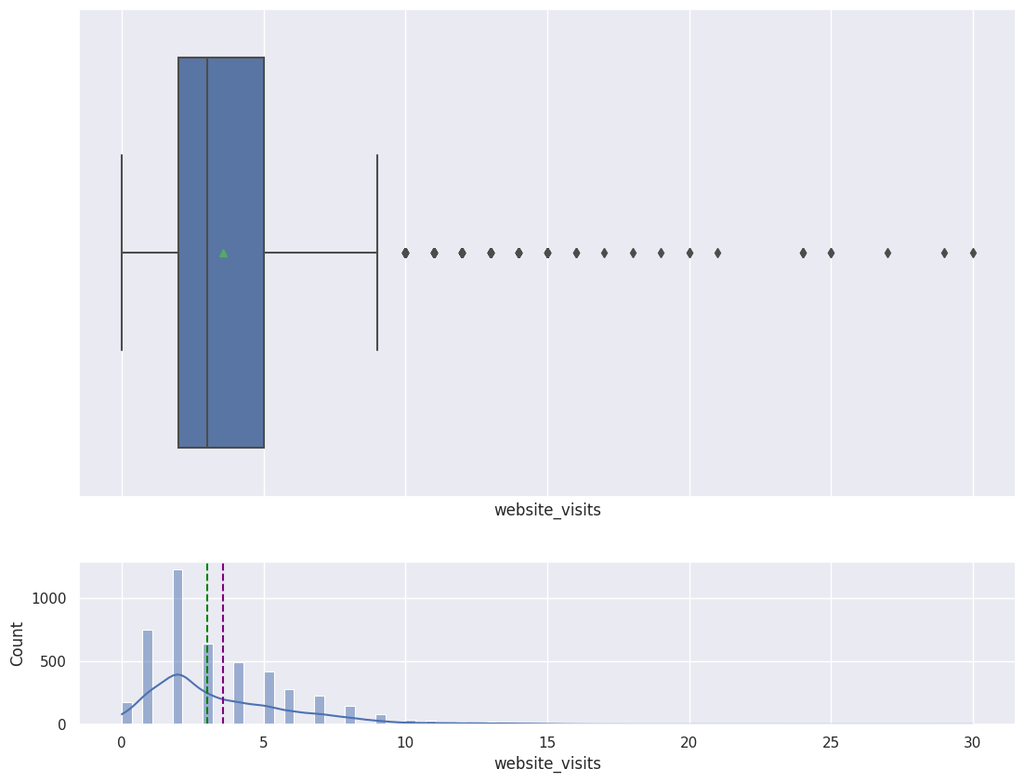

```python
histo_box(data, 'website_visits')
```

**Observations:**

- Looking at the boxplot, we see that though it is positively-skewed it has many outliers in it.
- Median of the data and mean of the data are very much the same.
- Most of the leads visit the website less than 5 times or around 2 to 3 times.

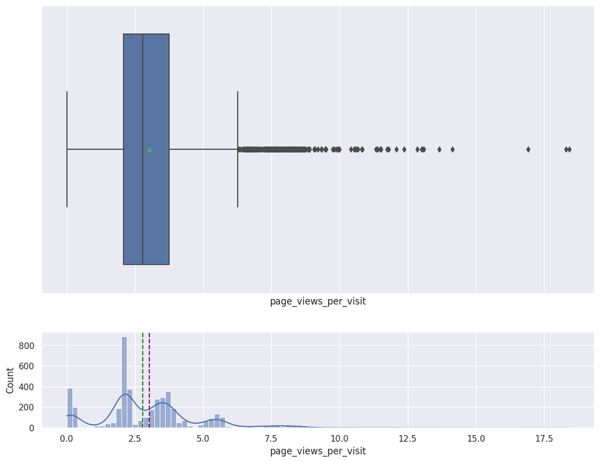

```python
histo_box(data, 'page_views_per_visit')
```

**Observations:**

- This data visual is similar to the previous visual which described about the no. of website visits.
- Although there are more outliers here compared to the last one.
- Most of the leads view around 3 pages for each website visit.

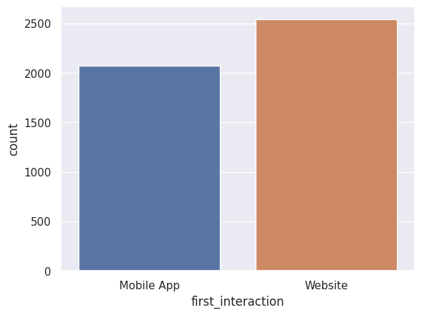

```python
sns.countplot(x = data['first_interaction'])
plt.show()
```